# 6th plate design, randomisation b

RT optimisation with the Labcyte Echo 525: TSO, RT primer and RNA amounts

```r
variant <- "b"
newseed <- 2
indexes <- c("CTCTCTAC", "CGAGGCTG", "AAGAGGCA", "GTAGAGGA", "GCTCATGA", "ATCTCAGG")
plateID <- "R"
```

# New test of TSO, RT primer and RNA amounts

In this design, the TSOs are randomised as much as possible (taking into account that all do not have the same stock concentrations).

Each 384-well plate is divided in 6 “sextants”, interleaved for easier collection of the reaction products. Each sextant has a different RNA amount, and is indexed and amplified independently. There are 9 × 7 combinations of TSO and RT primer concentrations, plus one negative control with no RNA. Each reaction is assigned to a random well within the sextant.

For each plate replicate, a different random seed is used, to generate different randomisations.

## Load scripts and libraries.

```r
library("magrittr")   # For its diamond pipe operators
library("ggplot2")    # For plotting
library("platetools") # For defining and manipulating 384-well plates
library("plyr")
library("tibble")     # For comfortable command-line operations

# The set_block function that will become part of platetools
source("https://raw.githubusercontent.com/charles-plessy/platetools/76213accb1704d11a2d96fb1f6284d0b46117778/R/set_block.R")

# Do not load the whole smallCAGEqc package, just get the barcode data.
data("nanoCAGE2017barcodes", package = "smallCAGEqc")
```

# Selected TSOs

TSOs are transferred as 1, 2 or 4 drops from 3 different starting concentrations in the source plate. Let’s call each starting concentration “Tier_A”, “Tier_B” or “Tier_C”. Given constraints on remaining volume, some TSOs can only be Tier_C, etc. Let’s refer to the TSOs by their numerical identifier. Tier_N is a set of barcodes that can be used for the negative control. See the file Labcyte-RT6_TSO_stock_to_source.xls for details on the cherrypicking of the TSOs.

```r
Tier_A <- c(  3, 15, 27, 39, 51, 63, 75
           , 10, 22, 34, 46, 58, 70, 82
           , 11, 23, 35, 47, 59, 71, 83)

Tier_B <- c(  1, 13, 25, 37, 49, 61, 73
           ,  2, 14, 26, 38, 50, 62, 74
           ,  7, 19, 31, 43, 55, 67, 79)

Tier_C <- c(  4, 16, 28, 40, 52, 64, 76
           ,  5, 17, 29, 41, 65, 77, 89
           ,  6, 18, 30, 42, 66, 78, 90)

Tier_N <- c(  8, 20, 32, 44, 68, 80, 92)
```

# Set Random seed

```r
set.seed(newseed)
```

# Creation of sextants

```r
createRandomisedSextant <- function(index, rna) {
  df <- data.frame ( BARCODE_ID = c( sample(Tier_A, 21)
                                   , sample(Tier_B, 21)
                                   , sample(Tier_C, 21)
                                   , sample(Tier_N,  1)))
  tsoMaxConc <- 800
  df$TSO_source <- c( rep(tsoMaxConc /  1, 21)
                    , rep(tsoMaxConc /  8, 21)
                    , rep(tsoMaxConc /  64, 21)
                    , tsoMaxConc / 32)
  df$TSO_vol <- c(rep(c(rep(100,7), rep(50,7), rep(25,7)),3), 25)
  df$TSO <- df$TSO_source * df$TSO_vol / 500
  df$RT_PRIMERS <- c(rep(c(0, 1, 2, 4, 8, 16, 24), 9), 1)
  df$RT_PRIMERS_vol <- 25
  df[df$RT_PRIMERS == 0, "RT_PRIMERS_vol"] <- 0
  df$MASTER_MIX_vol <- 350
  df$INDEX <- index
  df$RNA <- rna
  df$RNA_vol <- 25
  df[64, "RNA_vol"] <- 0
  df$H2O_vol <- 500 - df$RNA_vol - df$RT_PRIMERS_vol - df$TSO_vol - df$MASTER_MIX_vol
  df[sample(nrow(df)),]
}
```

# Sextants

## Plate layout

Create a data frame representing the contents of each well.

```r
plate           <- tibble(well = platetools::num_to_well(1:384, plate = "384"))
plate$row       <- sub("..$", "", plate$well) %>% factor
plate$col       <- sub("^.",  "", plate$well) %>% as.numeric %>% factor
```

## Fill sextants

```r
plate$sxt <- paste0 (
  c(rep("A", 8), rep("B", 8), rep("C", 8)),
  ifelse (plate$row %in% LETTERS[1:8 * 2], 2, 1)
) %>% factor

plate %<>% arrange(sxt)

plate %<>% cbind( rbind( createRandomisedSextant(indexes[1], 1e5)
                       , createRandomisedSextant(indexes[2], 1e4)
                       , createRandomisedSextant(indexes[3], 1e3)
                       , createRandomisedSextant(indexes[4], 1e2)
                       , createRandomisedSextant(indexes[5], 1e1)
                       , createRandomisedSextant(indexes[6], 1e0))
      ) %>% as.tibble()

plate$BARCODE_ID
```

```
##   [1] 90 61 73 74 71 83 63  3 46 82 70 43 34 42 22 52 51 62 11 10 75  7 66 17 13 37 38 77 19 47 41
##  [32] 15 26 76 78 59 23 27 79 65 67 30 49 29  1 14 39  5 89 40 55 20 64  6 16  2 18 31 28 35 58  4
##  [63] 25 50 89 27 67 15 59 32 22 34 64 61 14 42 47 43 78  5 82 16 30 79 13 50 17 39 46 11 19  4 23
##  [94]  6 38 10 73 62 49 26 41 37 70 71 40 66 25 18 65  3 35 31 83 58 28 77 76 52 55 29 75  7 74  2
## [125] 90 63  1 51 14 23 47 59 49 10  7 11 16 58 77  5 42 35  3 83 90 38 43 55 66 18 37  4 39 64 76
## [156] 20 34 71 46 28 30 19  6 41 13 52 63 15 78 70 65  1 82 73 61 67 75 29 50 17 26 51 74 62 79 22
## [187] 27  2 40 31 25 89 79 75 16 90 19 51  6 66 63 17 30 44 89 15 70 73 47 61 50 77 52  3 58 64 35
## [218] 10 38  1 40 42 83 28 22 29 31  4 37 76 14 18 74 59 26  7 27 49 78 34 71 62 11 23  5 43 39 13
## [249] 41 82 25 46 55  2 65 67 89 10  1 59 70 30 79  7 43 80 74 11 18 37 35 25 38 22 65 66 46  3 63
## [280] 17 51 41 34 58 52 77 55  5 62 47 19 42 15 75 64  2 49 13 71 27 82 39 26 23 14 78 73 28 31 83
## [311]  6 90 50 40 29 67  4 61 16 76 26 51 78  1 18 75  6 27 77 11 76 47 14 31 64 58 40 67 89 65 70
## [342]  7 71 19 59 52 82 44 25 55 13 10 61 42 49 34 41 37 30 63 50 62  3 16 28 43 79 23  5 83 39 15
## [373] 17 66 46 22 35 90  4  2 38 29 73 74
```

```r
plate$INDEX %<>% factor
plate$BARCODE_SEQ <- nanoCAGE2017barcodes[plate$BARCODE_ID, "barcodes"]

plate$RNA_level <- plate$RNA %>% factor(labels = paste0("RNA_", LETTERS[1:6]))
plate$RTP_level <- plate$RT_PRIMERS %>% factor(labels = paste0("RTP_", LETTERS[1:7]))

plate$RNA[plate$RNA_vol == 0] <- 0
plate$plateID <- plateID
```

# Summary

```r
plate
```

```
## # A tibble: 384 x 19
##    well  row   col   sxt   BARCODE_ID TSO_source TSO_vol    TSO RT_PRIMERS RT_PRIMERS_vol
##  * <chr> <fct> <fct> <fct>      <dbl>      <dbl>   <dbl>  <dbl>      <dbl>          <dbl>
##  1 A01   A     1     A1           90.       12.5     50.   1.25        16.            25.
##  2 A02   A     2     A1           61.      100.     100.  20.0         24.            25.
##  3 A03   A     3     A1           73.      100.     100.  20.0          4.            25.
##  4 A04   A     4     A1           74.      100.      50.  10.0          0.             0.
##  5 A05   A     5     A1           71.      800.      50.  80.0         24.            25.
##  6 A06   A     6     A1           83.      800.     100. 160.           4.            25.
##  7 A07   A     7     A1           63.      800.      25.  40.0          1.            25.
##  8 A08   A     8     A1            3.      800.      25.  40.0          4.            25.
##  9 C01   C     1     A1           46.      800.     100. 160.           2.            25.
## 10 C02   C     2     A1           82.      800.      50.  80.0          4.            25.
## # ... with 374 more rows, and 9 more variables: MASTER_MIX_vol <dbl>, INDEX <fct>, RNA <dbl>,
## #   RNA_vol <dbl>, H2O_vol <dbl>, BARCODE_SEQ <chr>, RNA_level <fct>, RTP_level <fct>,
## #   plateID <chr>
```

```r
summary(plate)
```

```
##      well                row           col      sxt       BARCODE_ID      TSO_source
##  Length:384         A      : 24   1      : 16   A1:64   Min.   : 1.00   Min.   : 12.5
##  Class :character   B      : 24   2      : 16   A2:64   1st Qu.:19.75   1st Qu.: 12.5
##  Mode  :character   C      : 24   3      : 16   B1:64   Median :41.00   Median :100.0
##                     D      : 24   4      : 16   B2:64   Mean   :42.55   Mean   :299.8
##                     E      : 24   5      : 16   C1:64   3rd Qu.:65.00   3rd Qu.:800.0
##                     F      : 24   6      : 16   C2:64   Max.   :90.00   Max.   :800.0
##                     (Other):240   (Other):288
##     TSO_vol            TSO            RT_PRIMERS    RT_PRIMERS_vol  MASTER_MIX_vol      INDEX
##  Min.   : 25.00   Min.   :  0.625   Min.   : 0.00   Min.   : 0.00   Min.   :350    AAGAGGCA:64
##  1st Qu.: 25.00   1st Qu.:  2.500   1st Qu.: 1.00   1st Qu.:25.00   1st Qu.:350    ATCTCAGG:64
##  Median : 50.00   Median : 10.000   Median : 4.00   Median :25.00   Median :350    CGAGGCTG:64
##  Mean   : 57.81   Mean   : 34.951   Mean   : 7.75   Mean   :21.48   Mean   :350    CTCTCTAC:64
##  3rd Qu.:100.00   3rd Qu.: 40.000   3rd Qu.:16.00   3rd Qu.:25.00   3rd Qu.:350    GCTCATGA:64
##  Max.   :100.00   Max.   :160.000   Max.   :24.00   Max.   :25.00   Max.   :350    GTAGAGGA:64
##
##       RNA            RNA_vol         H2O_vol       BARCODE_SEQ        RNA_level  RTP_level
##  Min.   :     0   Min.   : 0.00   Min.   :  0.00   Length:384         RNA_A:64   RTP_A:54
##  1st Qu.:    10   1st Qu.:25.00   1st Qu.:  0.00   Class :character   RNA_B:64   RTP_B:60
##  Median :   100   Median :25.00   Median : 50.00   Mode  :character   RNA_C:64   RTP_C:54
##  Mean   : 18229   Mean   :24.61   Mean   : 46.09                      RNA_D:64   RTP_D:54
##  3rd Qu.: 10000   3rd Qu.:25.00   3rd Qu.: 75.00                      RNA_E:64   RTP_E:54
##  Max.   :100000   Max.   :25.00   Max.   :100.00                      RNA_F:64   RTP_F:54
##                                                                                  RTP_G:54
##    plateID
##  Length:384
##  Class :character
##  Mode  :character
##
##
##
##
```

```r
write.table(plate, paste0("plate6", variant, ".txt"), sep = "\t", quote = FALSE, row.names = FALSE)
```

# Plate maps

```r
plateMap <- function(x, title) {
  platetools::raw_map(plate[[x]], well=plate$well, plate="384") +
  ggtitle(title) +
  viridis::scale_fill_viridis(breaks = unique(plate[[x]]))
}

plateMapLog <- function(x, title) {
  platetools::raw_map(plate[[x]], well=plate$well, plate="384") +
  ggtitle(title) +
  viridis::scale_fill_viridis(breaks = unique(plate[[x]]), trans = "log")
}
```

## TSO

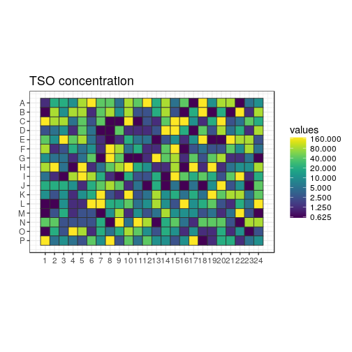

```r
(plot_TSO <- plateMapLog("TSO", "TSO concentration"))
```

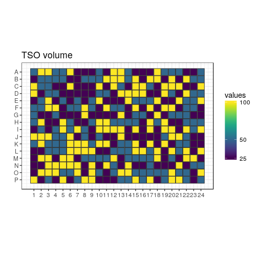

```r
(plot_TSO_vol <- plateMap("TSO_vol", "TSO volume"))
```

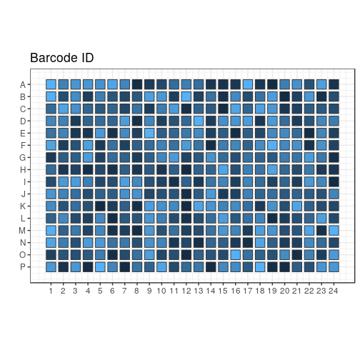

```r
(plot_BARCODES <- platetools::raw_map(plate[["BARCODE_ID"]], well=plate$well, plate="384") +
  ggtitle("Barcode ID")) + theme(legend.position="none")
```

## Indexes

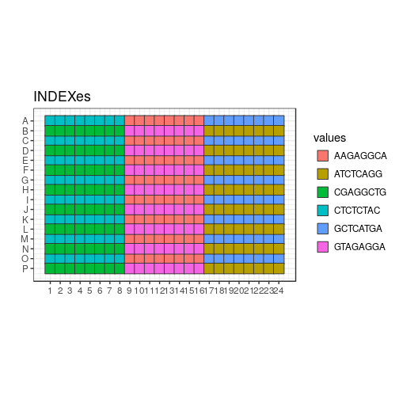

```r
(plot_indexes <- platetools::raw_map(plate[["INDEX"]], well=plate$well, plate="384") +
  ggtitle("INDEXes"))
```

## H2O

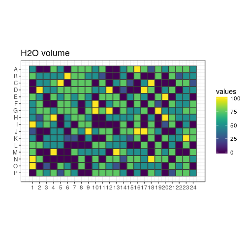

```r
(plot_H2O_vol <- plateMap("H2O_vol", "H2O volume"))
```

## RT primers

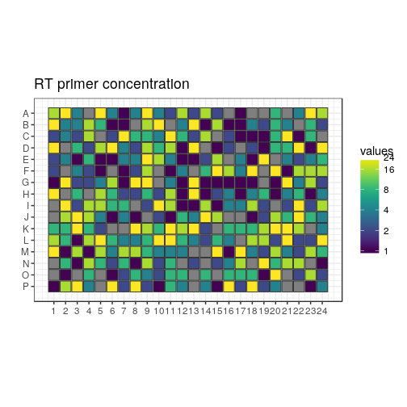

```r
(plot_RT <- plateMapLog("RT_PRIMERS", "RT primer concentration"))
```

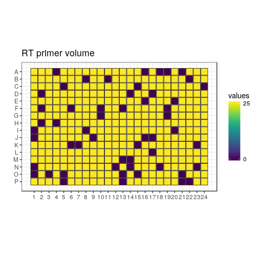

```r
(plot_RT_vol <- plateMap("RT_PRIMERS_vol", "RT primer volume"))
```

## RNA mass

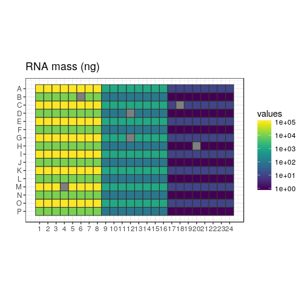

```r
(plot_RNA <- plateMapLog("RNA", "RNA mass (ng)"))
```

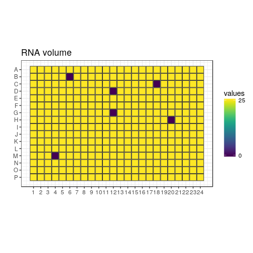

```r
(plot_RNA_vol <- plateMap("RNA_vol", "RNA volume"))
```

# Transfer file

## Source plate layout

### TSO

```r
nanoCAGE2017barcodes$well <- unlist(lapply(LETTERS[1:8], function(x) paste(x, sprintf("%02d", 1:12), sep = "")))

tso_block <- data.frame( id  = c(Tier_A, Tier_B, Tier_C, Tier_N)
                       , row = unlist(lapply(LETTERS[1:10], rep, 7))
                       , col = rep(1:7, 10))

tso_block$well <- paste0(tso_block$row, "0", tso_block$col)

tso_block$barcodes <- nanoCAGE2017barcodes[tso_block$id, "barcodes"]

source <- tibble(well = platetools::num_to_well(1:384, plate = "384"))

for (n in 1:nrow(tso_block))
  source %<>% set_block( tso_block[n,"well"]
                       , tso_block[n,"barcodes"]
                       , 20000)
```

### Water

```r
source %<>% set_block("M01~M06", "H2O", 20000)
```

### RNA

```r
levels(plate$RNA %>% factor)
```

```
## [1] "0"     "1"     "10"    "100"   "1000"  "10000" "1e+05"
```

```r
levels(plate$RNA_level)
```

```
## [1] "RNA_A" "RNA_B" "RNA_C" "RNA_D" "RNA_E" "RNA_F"
```

```r
source %<>% set_block("L01", "RNA_F", 20000)
source %<>% set_block("L02", "RNA_E", 20000)
source %<>% set_block("L03", "RNA_D", 20000)
source %<>% set_block("L04", "RNA_C", 20000)
source %<>% set_block("L05", "RNA_B", 20000)
source %<>% set_block("L06", "RNA_A", 20000)
```

```r
levels(plate$RT_PRIMERS %>% factor)
```

```
## [1] "0"  "1"  "2"  "4"  "8"  "16" "24"
```

```r
levels(plate$RTP_level)
```

```
## [1] "RTP_A" "RTP_B" "RTP_C" "RTP_D" "RTP_E" "RTP_F" "RTP_G"
```

```r
source %<>% set_block("K01", "RTP_A", 20000)
source %<>% set_block("K02", "RTP_B", 20000)
source %<>% set_block("K03", "RTP_C", 20000)
source %<>% set_block("K04", "RTP_D", 20000)
source %<>% set_block("K05", "RTP_E", 20000)
source %<>% set_block("K06", "RTP_F", 20000)
source %<>% set_block("K07", "RTP_G", 20000)
```

## Plan plate

```r
planPlate <- tibble(well = platetools::num_to_well(1:384, plate = "384"))

for (n in 1:nrow(plate)) {
  planPlate %<>% set_block( plate[[n,"well"]]
                          , plate[[n,"BARCODE_SEQ"]] %>% as.character
                          , plate[[n,"TSO_vol"]])
  planPlate %<>% set_block( plate[[n,"well"]]
                          , "H2O"
                          , plate[[n,"H2O_vol"]])
  planPlate %<>% set_block( plate[[n,"well"]]
                          , plate[[n,"RTP_level"]] %>% as.character
                          , plate[[n,"RT_PRIMERS_vol"]])
  planPlate %<>% set_block( plate[[n,"well"]]
                          , plate[[n,"RNA_level"]] %>% as.character
                          , plate[[n,"RNA_vol"]])
}
planPlate %<>% replace( . == 0, NA)
```

## Plan transfer

```r
source("plates.R")
source("echo.R")

planPlate   <- Plate(plate = planPlate)
sourcePlate <- Plate(plate = source)
destPlate   <- Plate(plate = tibble::tibble(well = num_to_well(1:384, plate = "384")))

echo <- planTransfers(sourcePlate, destPlate, planPlate)
echo
```

```
## A 525 Echo machine:
##   Source plate:      A Plate with data about 384 wells (dead volume: 10000; max volume: 1e+05).
##   Destination plate: A Plate with data about 384 wells (dead volume: 10000; max volume: 1e+05).
## Transducer at the following coordinates:
##   Source:      L06 (384-well format)
##   Destination: P24 (384-well format)
## 1368 elements in the log.
```

```r
transfers <- as.data.frame(echo %>% showLogs)
transfers <- transfers[order(transfers$from),]

colnames(transfers) <- c("Source well", "Destination well", "Transfer volume", "what")

transfers
```

```
##      Source well Destination well Transfer volume   what
## 604          A01              A08              25 ACACTC
## 605          A01              C15             100 ACACTC
## 606          A01              E22              50 ACACTC
## 607          A01              F14              25 ACACTC
## 608          A01              L06             100 ACACTC
## 609          A01              L19              25 ACACTC
## 856          A02              B04              50 AGTCTC
## 857          A02              D14             100 AGTCTC
## 858          A02              G08             100 AGTCTC
## 859          A02              I16              25 AGTCTC
## 860          A02              I21              25 AGTCTC
## 861          A02              N20              25 AGTCTC
## 892          A03              B02              50 ATCTGA
## 893          A03              B24              50 ATCTGA
```

[output cut: 1354 more lines]

```r
write.table( transfers[,1:3], file = paste0("Exp7_plate1", variant, ".csv")
           , quote = FALSE, row.names = FALSE, col.names = TRUE, sep = ",")
```